# Case Study 2

```r
t.test(my_data2$PercentSalaryHike~my_data2$Attrition)
```

```
##
##  Welch Two Sample t-test
##
## data:  my_data2$PercentSalaryHike by my_data2$Attrition
## t = -0.42788, df = 187.22, p-value = 0.6692
## alternative hypothesis: true difference in means between group No and group Yes is not equal to 0
## 95 percent confidence interval:
##  -0.8596808  0.5532229
## sample estimates:
##  mean in group No mean in group Yes
##          15.17534          15.32857
```

```r
t.test(my_data2$YearsSinceLastPromotion~my_data2$Attrition)
```

```
##
##  Welch Two Sample t-test
##
## data:  my_data2$YearsSinceLastPromotion by my_data2$Attrition
## t = 0.12796, df = 187.59, p-value = 0.8983
## alternative hypothesis: true difference in means between group No and group Yes is not equal to 0
## 95 percent confidence interval:
##  -0.5712911  0.6505475
## sample estimates:
##  mean in group No mean in group Yes
##          2.175342          2.135714
```

```r
my_data3 = my_data2[setdiff(colnames(my_data2), c('YearsSinceLastPromotion', 'PercentSalaryHike'))]
dim(my_data3)
```

```
## [1] 870  27
```

We can not explore relationships between continuous variables by using a scatter plot and correlation matrix. It gives a board overview of correlations between continuous variables.

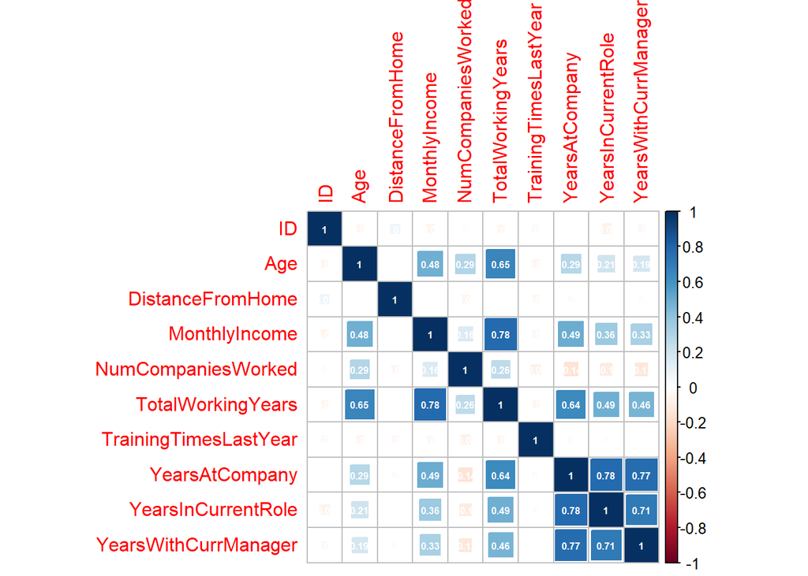

```r
#my_data3$AttritionBin <- ifelse(my_data3$Attrition == "Yes",1,0)


#my_data3corr = my_data3[setdiff(colnames(my_data3), c('Attrition','ID'))]


#my_data3_numericcorr <- dplyr::select_if(my_data3corr, is.numeric)


heatmap.cor <- function(df){
  df %>%
    keep(is.numeric) %>%
    drop_na() %>%
    cor %>%
    corrplot( addCoef.col = 'white',
             number.digits = 2,
             number.cex = 0.5,
             method = 'square')
}
heatmap.cor(my_data3)
```

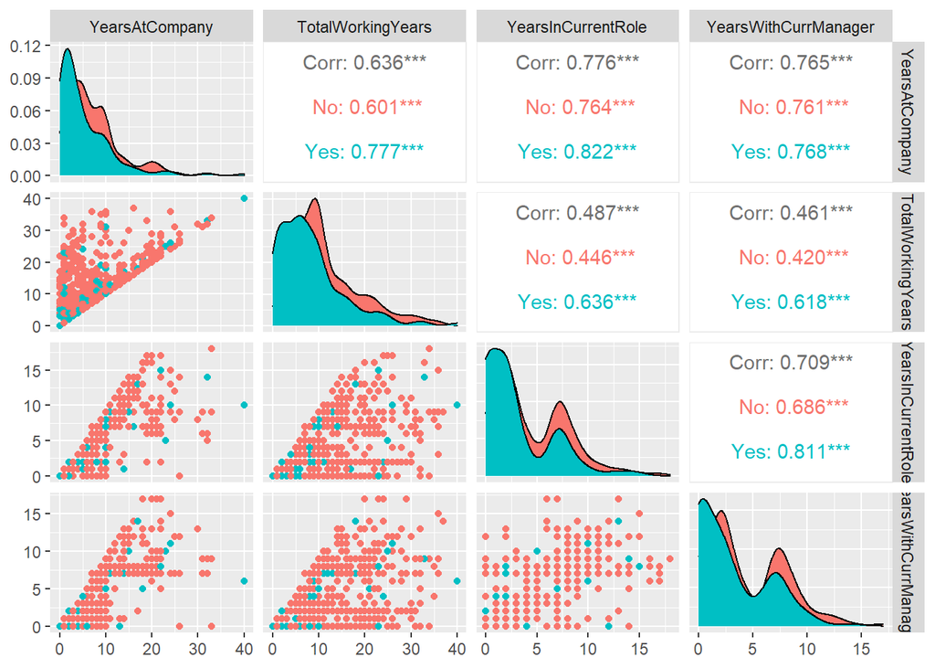

```r
ggpairs(my_data3,columns=c('YearsAtCompany','TotalWorkingYears','YearsInCurrentRole' , 'YearsWithCurrManager'),aes(colour=Attrition))
```

```r
my_data3 = my_data3[setdiff(colnames(my_data3), c('TotalWorkingYears','YearsInCurrentRole' , 'YearsWithCurrManager'))]
```

Now we can explore the continuous variables to determine if they need to be transformed by using a histogram. Some variables have a bit of a right skew but nothing too drastic we will assume normality and proceed with caution.

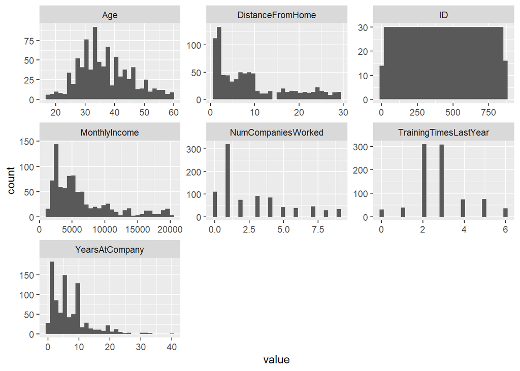

```r
# histogram of all numeric variables
my_data3 %>% keep(is.numeric) %>% gather %>% ggplot(aes(x = value)) + facet_wrap(~key, scales = "free")+ geom_histogram()
```

We then proceeded to do the same EDA for categorical variables.

```r
#cross table to look at cat variables to see how they relate to the response

#my_data3_factor <- dplyr::select_if(my_data3, is.factor)

#CrossTable(my_data3$Department, my_data3$Attrition, prop.r = TRUE, prop.c = FALSE, prop.chisq = FALSE)


#CrossTable(my_data3$EnvironmentSatisfaction, my_data3$Attrition, prop.r = TRUE, prop.c = FALSE, prop.chisq = FALSE)


#CrossTable(my_data3$JobRole, my_data3$Attrition, prop.r = TRUE, prop.c = FALSE, prop.chisq = FALSE)


#CrossTable(my_data3$Gender, my_data3$Attrition, prop.r = TRUE, prop.c = FALSE, prop.chisq = FALSE)


#CrossTable(my_data3$MaritalStatus, my_data3$Attrition, prop.r = TRUE, prop.c = FALSE, prop.chisq = FALSE)


#CrossTable(my_data3$RelationshipSatisfaction, my_data3$Attrition, prop.r = TRUE, prop.c = FALSE, prop.chisq = FALSE)



#CrossTable(my_data3$WorkLifeBalance, my_data3$Attrition, prop.r = TRUE, prop.c = FALSE, prop.chisq = FALSE)



#CrossTable(my_data3$MonthlyIncomecat, my_data3$Attrition, prop.r = TRUE, prop.c = FALSE, prop.chisq = FALSE)



#CrossTable(my_data3$EducationField, my_data3$Attrition, prop.r = TRUE, prop.c = FALSE, prop.chisq = FALSE)


#CrossTable(my_data3$BusinessTravel, my_data3$Attrition, prop.r = TRUE, prop.c = FALSE, prop.chisq = FALSE)



#CrossTable(my_data3$StockOptionLevel, my_data3$Attrition, prop.r = TRUE, prop.c = FALSE, prop.chisq = FALSE)
```

Quick visuals of factor variables to determine if there is any correlation between factors and attrition

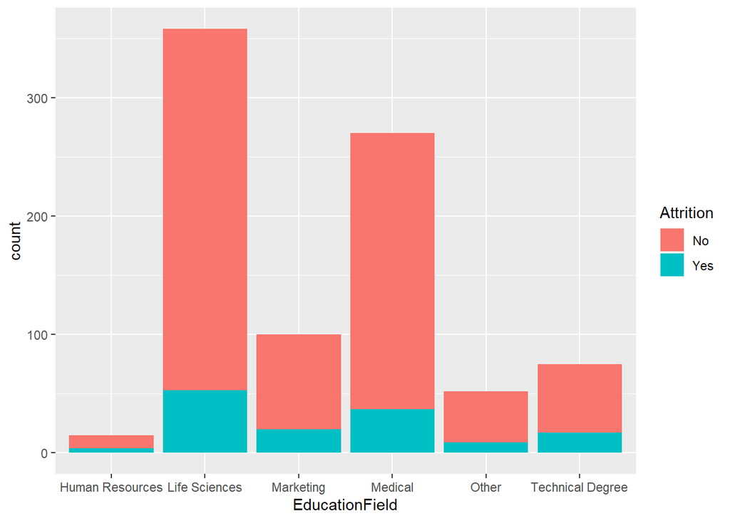

```r
 ggplot(my_data3, aes(EducationField, fill = Attrition)) + geom_bar()
```

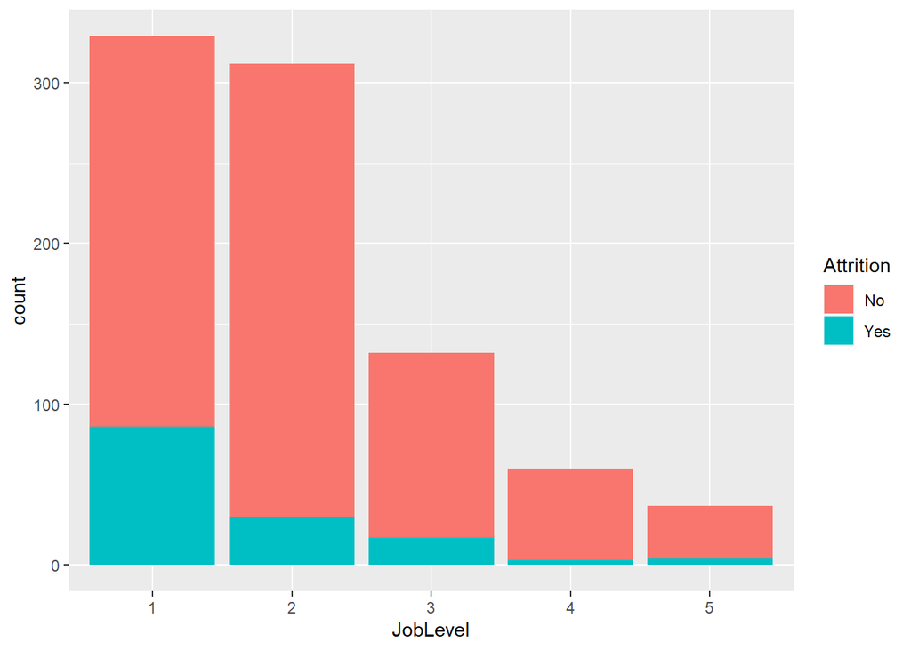

```r
ggplot(my_data3, aes(JobLevel, fill = Attrition)) + geom_bar()
```

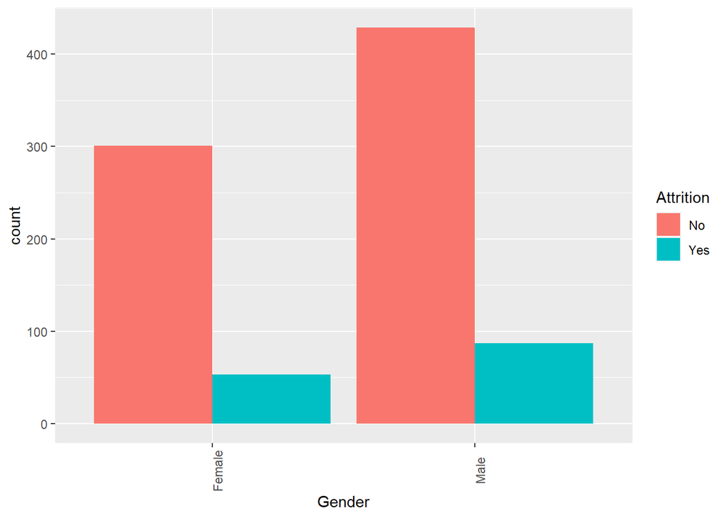

```r
 ggplot(my_data3, aes(x = Gender, fill = Attrition)) +
  geom_bar(position = "dodge") +
  theme(axis.text.x = element_text(angle = 90))
```

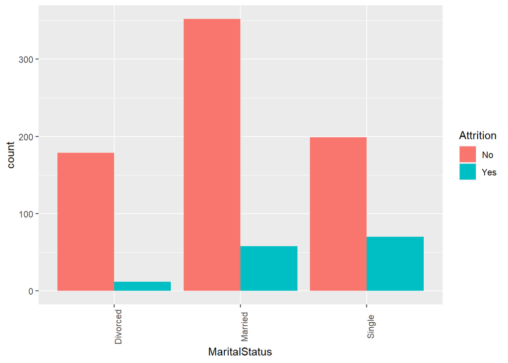

```r
ggplot(my_data3, aes(x = MaritalStatus, fill = Attrition)) +
  geom_bar(position = "dodge") +
  theme(axis.text.x = element_text(angle = 90))
```

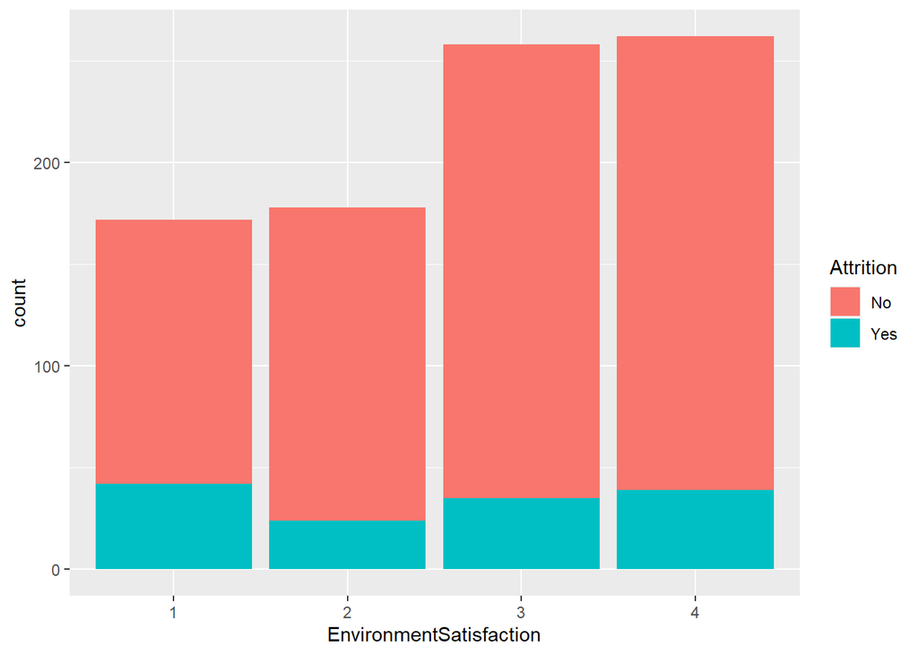

```r
ggplot(my_data3, aes(EnvironmentSatisfaction, fill = Attrition)) + geom_bar()
```

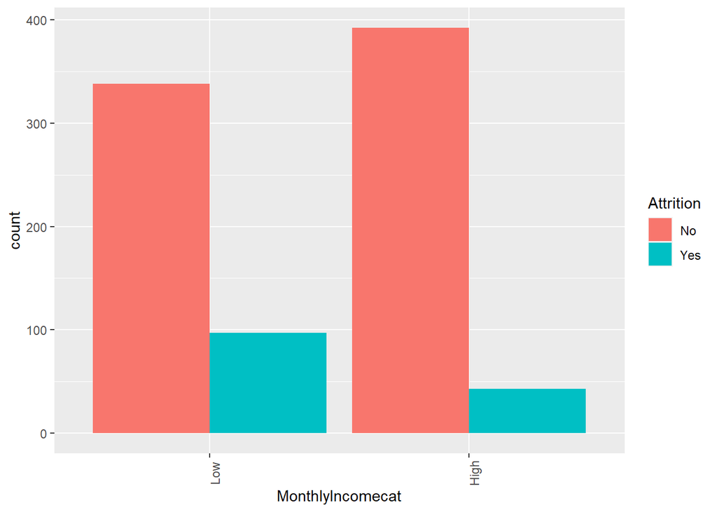

```r
ggplot(my_data3, aes(JobRole, fill = Attrition)) + geom_bar() -> h3


ggplot(my_data3, aes(x = MonthlyIncomecat, fill = Attrition)) +
  geom_bar(position = "dodge") +
  theme(axis.text.x = element_text(angle = 90))
```

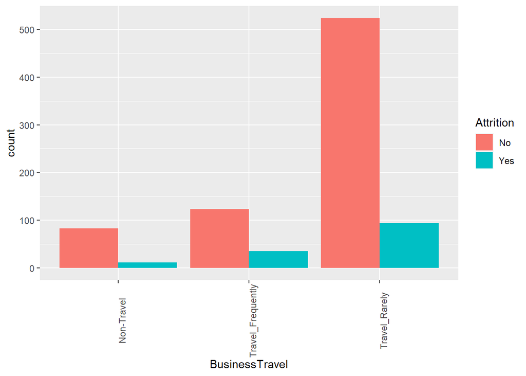

```r
ggplot(my_data3, aes(x = BusinessTravel, fill = Attrition)) +
  geom_bar(position = "dodge") +
  theme(axis.text.x = element_text(angle = 90))
```

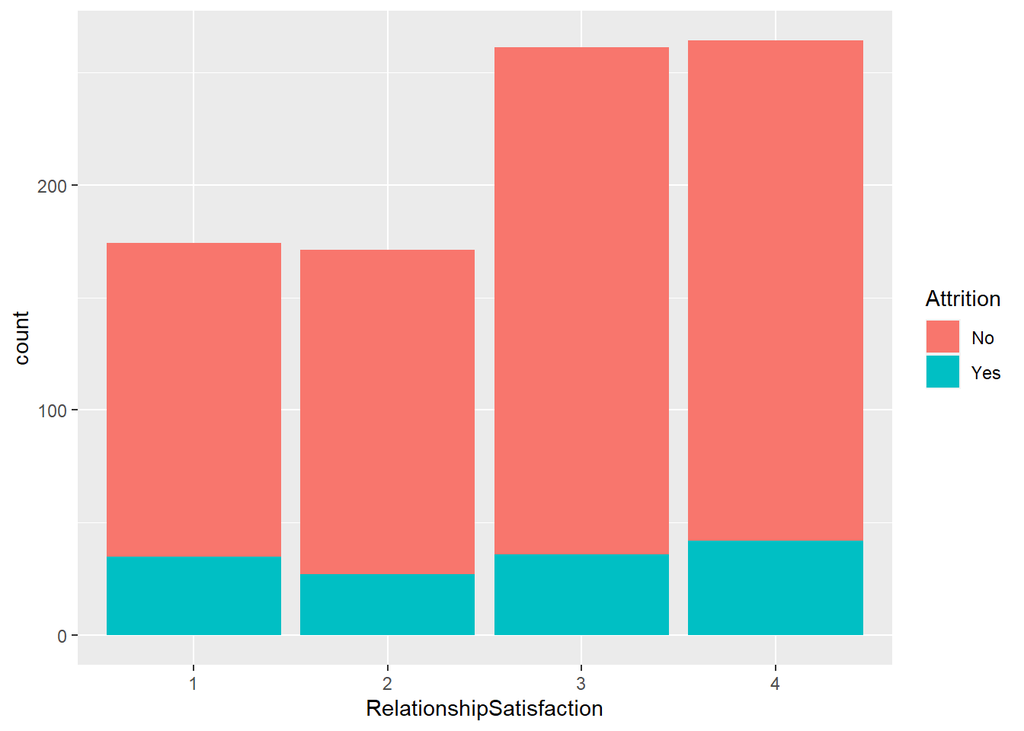

```r
ggplot(my_data3, aes(RelationshipSatisfaction, fill = Attrition)) + geom_bar()
```

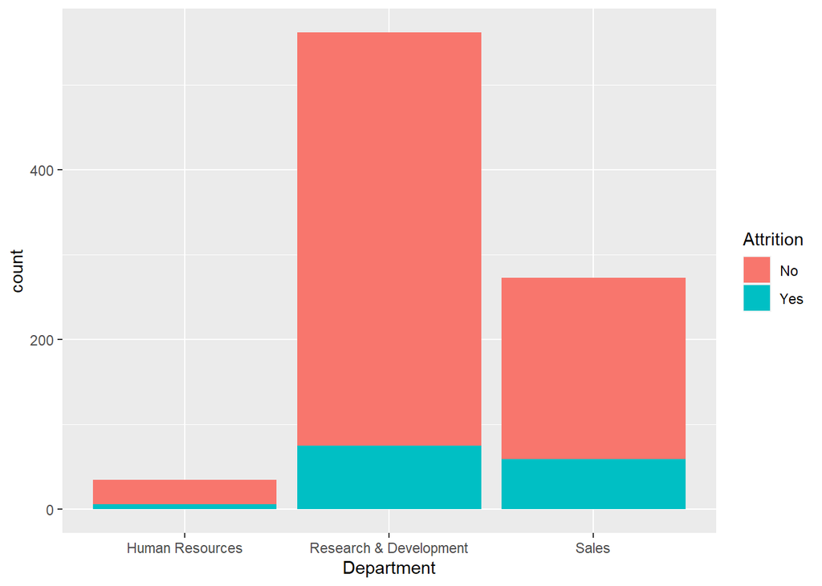

```r
ggplot(my_data3, aes(Department, fill = Attrition)) + geom_bar()
```

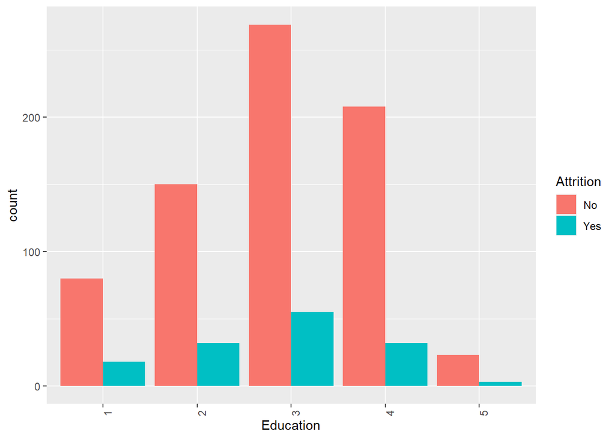

```r
ggplot(my_data3, aes(x = Education, fill = Attrition)) +
  geom_bar(position = "dodge") +
  theme(axis.text.x = element_text(angle = 90))
```

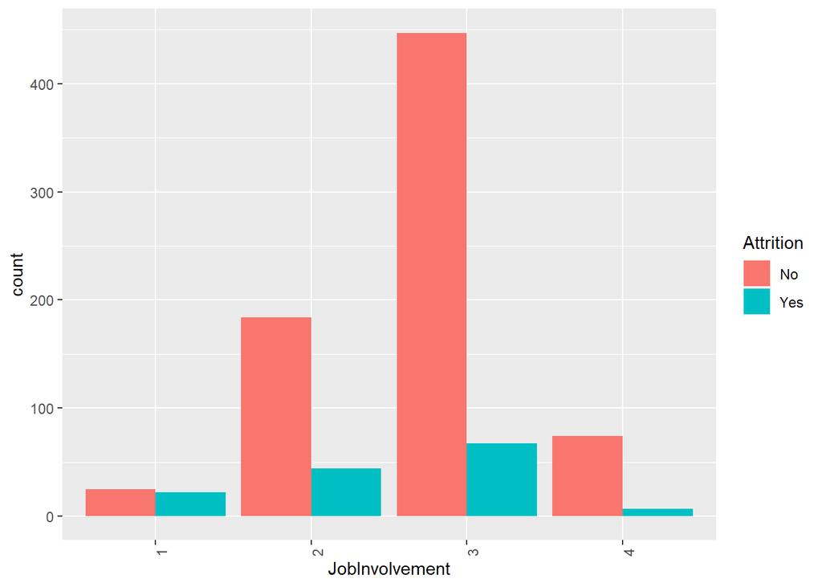

```r
ggplot(my_data3, aes(x = JobInvolvement, fill = Attrition)) +
  geom_bar(position = "dodge") +
  theme(axis.text.x = element_text(angle = 90))
```

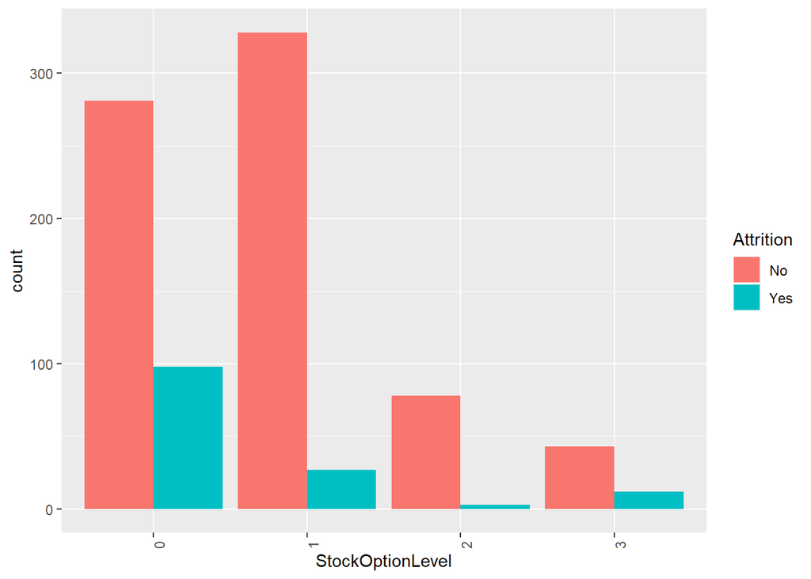

```r
ggplot(my_data3, aes(x = StockOptionLevel, fill = Attrition)) +
  geom_bar(position = "dodge") +
  theme(axis.text.x = element_text(angle = 90))
```

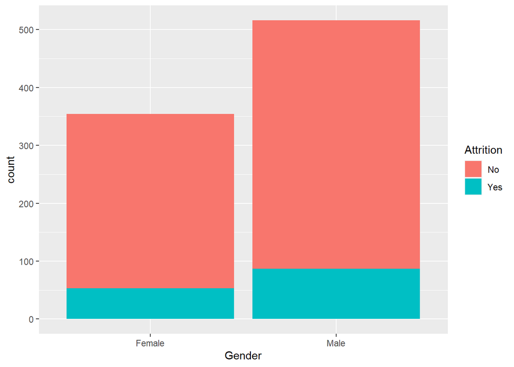

```r
ggplot(my_data3, aes(Gender, fill = Attrition)) + geom_bar()
```

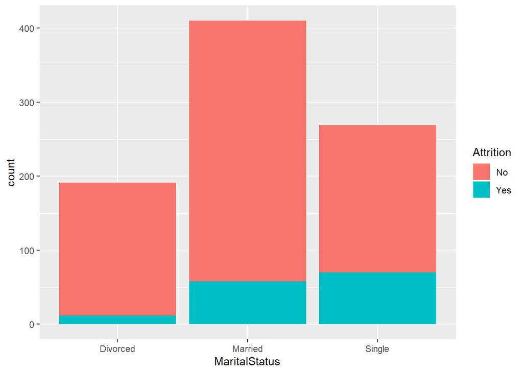

```r
ggplot(my_data3, aes(MaritalStatus, fill = Attrition)) + geom_bar()
```

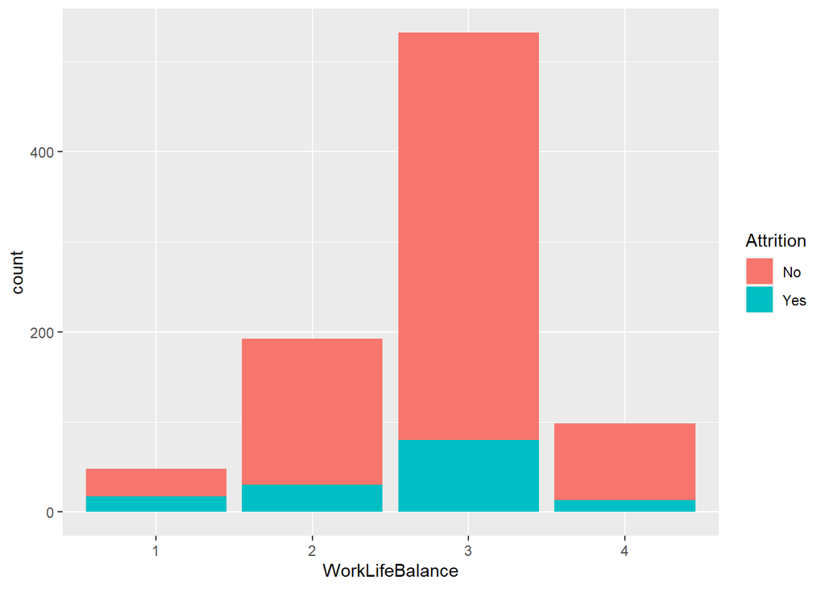

```r
ggplot(my_data3, aes(WorkLifeBalance, fill = Attrition)) + geom_bar()
```

```r
library(MASS)
library(tidyverse)
library(car)
my_data4 = my_data3[setdiff(colnames(my_data3), c('ID', 'MonthlyIncomecat', 'OverTimeDummy', 'GenderDummy', 'AttritionBin'))]

my_data4$AttritionBin <- ifelse(my_data3$Attrition == "Yes",1,0)

standardize = preProcess(my_data4, method = c("center", "scale"))
standardized.my_data3 = predict(standardize, my_data4)


full.log<-glm(Attrition~., data = my_data4, family = binomial('logit'), maxit = 100)

summary(full.log)
```

```
##
## Call:
## glm(formula = Attrition ~ ., family = binomial("logit"), data = my_data4,
##     maxit = 100)
##
## Deviance Residuals:
##        Min          1Q      Median          3Q         Max
## -5.377e-07  -5.377e-07  -5.377e-07  -5.377e-07   5.377e-07
##
## Coefficients:
##                                    Estimate Std. Error z value Pr(>|z|)
## (Intercept)                      -2.957e+01  9.952e+05       0        1
## Age                              -6.554e-13  7.600e+03       0        1
## BusinessTravelTravel_Frequently   6.498e-12  2.148e+05       0        1
## BusinessTravelTravel_Rarely       4.587e-12  1.829e+05       0        1
## DepartmentResearch & Development -8.236e-12  7.283e+05       0        1
## DepartmentSales                   3.829e-12  7.535e+05       0        1
## DistanceFromHome                 -7.838e-14  6.970e+03       0        1
## Education2                       -4.838e-12  2.068e+05       0        1
## Education3                       -7.592e-12  1.903e+05       0        1
## Education4                       -7.027e-12  2.048e+05       0        1
## Education5                       -1.854e-11  3.688e+05       0        1
## EducationFieldLife Sciences      -1.624e-11  5.605e+05       0        1
## EducationFieldMarketing          -2.591e-12  5.960e+05       0        1
## EducationFieldMedical            -2.380e-11  5.613e+05       0        1
## EducationFieldOther              -2.411e-11  6.016e+05       0        1
## EducationFieldTechnical Degree   -1.910e-11  5.830e+05       0        1
## EnvironmentSatisfaction2         -7.575e-12  1.751e+05       0        1
## EnvironmentSatisfaction3         -1.274e-11  1.621e+05       0        1
## EnvironmentSatisfaction4         -1.090e-11  1.617e+05       0        1
## GenderMale                       -3.266e-12  1.134e+05       0        1
## JobInvolvement2                  -1.353e-10  2.644e+05       0        1
## JobInvolvement3                  -1.335e-10  2.545e+05       0        1
## JobInvolvement4                  -1.303e-10  3.053e+05       0        1
## JobLevel2                         4.929e-13  2.461e+05       0        1
## JobLevel3                         6.706e-12  4.099e+05       0        1
## JobLevel4                         2.188e-11  6.376e+05       0        1
## JobLevel5                         3.630e-11  8.055e+05       0        1
## JobRoleHuman Resources           -3.492e-12  7.901e+05       0        1
## JobRoleLaboratory Technician     -5.258e-12  2.919e+05       0        1
```

[output cut: 19 more lines]

```
## StockOptionLevel3                -3.327e-11  2.831e+05       0        1
## TrainingTimesLastYear             2.059e-12  4.407e+04       0        1
## WorkLifeBalance2                 -2.766e-11  2.659e+05       0        1
## WorkLifeBalance3                 -2.838e-11  2.497e+05       0        1
## WorkLifeBalance4                 -3.193e-11  2.904e+05       0        1
## YearsAtCompany                    6.168e-13  1.156e+04       0        1
## AttritionBin                      5.913e+01  1.804e+05       0        1
##
## (Dispersion parameter for binomial family taken to be 1)
##
##     Null deviance: 7.6767e+02  on 869  degrees of freedom
## Residual deviance: 2.5152e-10  on 815  degrees of freedom
## AIC: 110
##
## Number of Fisher Scoring iterations: 28
```

```r
exp(cbind("Odds ratio" = coef(full.log), confint.default(full.log, level = 0.95)))
```

```
##                                    Odds ratio        2.5 %       97.5 %
## (Intercept)                      1.444174e-13 0.000000e+00          Inf
## Age                              1.000000e+00 0.000000e+00          Inf
## BusinessTravelTravel_Frequently  1.000000e+00 0.000000e+00          Inf
## BusinessTravelTravel_Rarely      1.000000e+00 0.000000e+00          Inf
## DepartmentResearch & Development 1.000000e+00 0.000000e+00          Inf
## DepartmentSales                  1.000000e+00 0.000000e+00          Inf
## DistanceFromHome                 1.000000e+00 0.000000e+00          Inf
## Education2                       1.000000e+00 0.000000e+00          Inf
## Education3                       1.000000e+00 0.000000e+00          Inf
## Education4                       1.000000e+00 0.000000e+00          Inf
## Education5                       1.000000e+00 0.000000e+00          Inf
## EducationFieldLife Sciences      1.000000e+00 0.000000e+00          Inf
## EducationFieldMarketing          1.000000e+00 0.000000e+00          Inf
## EducationFieldMedical            1.000000e+00 0.000000e+00          Inf
## EducationFieldOther              1.000000e+00 0.000000e+00          Inf
## EducationFieldTechnical Degree   1.000000e+00 0.000000e+00          Inf
## EnvironmentSatisfaction2         1.000000e+00 0.000000e+00          Inf
## EnvironmentSatisfaction3         1.000000e+00 0.000000e+00          Inf
## EnvironmentSatisfaction4         1.000000e+00 0.000000e+00          Inf
## GenderMale                       1.000000e+00 0.000000e+00          Inf
## JobInvolvement2                  1.000000e+00 0.000000e+00          Inf
## JobInvolvement3                  1.000000e+00 0.000000e+00          Inf
## JobInvolvement4                  1.000000e+00 0.000000e+00          Inf
## JobLevel2                        1.000000e+00 0.000000e+00          Inf
## JobLevel3                        1.000000e+00 0.000000e+00          Inf
## JobLevel4                        1.000000e+00 0.000000e+00          Inf
## JobLevel5                        1.000000e+00 0.000000e+00          Inf
## JobRoleHuman Resources           1.000000e+00 0.000000e+00          Inf
## JobRoleLaboratory Technician     1.000000e+00 0.000000e+00          Inf
## JobRoleManager                   1.000000e+00 0.000000e+00          Inf
## JobRoleManufacturing Director    1.000000e+00 0.000000e+00          Inf
## JobRoleResearch Director         1.000000e+00 0.000000e+00          Inf
## JobRoleResearch Scientist        1.000000e+00 0.000000e+00          Inf
## JobRoleSales Executive           1.000000e+00 0.000000e+00          Inf
## JobRoleSales Representative      1.000000e+00 0.000000e+00          Inf
## JobSatisfaction2                 1.000000e+00 0.000000e+00          Inf
## JobSatisfaction3                 1.000000e+00 0.000000e+00          Inf
## JobSatisfaction4                 1.000000e+00 0.000000e+00          Inf
## MaritalStatusMarried             1.000000e+00 0.000000e+00          Inf
## MaritalStatusSingle              1.000000e+00 0.000000e+00          Inf
## MonthlyIncome                    1.000000e+00 2.622531e-47 3.813111e+46
## NumCompaniesWorked               1.000000e+00 0.000000e+00          Inf
## OverTimeYes                      1.000000e+00 0.000000e+00          Inf
## RelationshipSatisfaction2        1.000000e+00 0.000000e+00          Inf
## RelationshipSatisfaction3        1.000000e+00 0.000000e+00          Inf
## RelationshipSatisfaction4        1.000000e+00 0.000000e+00          Inf
## StockOptionLevel1                1.000000e+00 0.000000e+00          Inf
## StockOptionLevel2                1.000000e+00 0.000000e+00          Inf
## StockOptionLevel3                1.000000e+00 0.000000e+00          Inf
## TrainingTimesLastYear            1.000000e+00 0.000000e+00          Inf
## WorkLifeBalance2                 1.000000e+00 0.000000e+00          Inf
## WorkLifeBalance3                 1.000000e+00 0.000000e+00          Inf
## WorkLifeBalance4                 1.000000e+00 0.000000e+00          Inf
## YearsAtCompany                   1.000000e+00 0.000000e+00          Inf
## AttritionBin                     4.794994e+25 0.000000e+00          Inf
```

```r
step.log<-full.log %>% stepAIC(trace=FALSE)

summary(step.log)
```

```
##
## Call:
## glm(formula = Attrition ~ AttritionBin, family = binomial("logit"),
##     data = my_data4, maxit = 100)
##
## Deviance Residuals:
##        Min          1Q      Median          3Q         Max
## -5.377e-07  -5.377e-07  -5.377e-07  -5.377e-07   5.377e-07
##
## Coefficients:
##               Estimate Std. Error z value Pr(>|z|)
## (Intercept)     -29.57   59071.98  -0.001        1
## AttritionBin     59.13  147259.01   0.000        1
##
## (Dispersion parameter for binomial family taken to be 1)
##
##     Null deviance: 7.6767e+02  on 869  degrees of freedom
## Residual deviance: 2.5152e-10  on 868  degrees of freedom
## AIC: 4
##
## Number of Fisher Scoring iterations: 28
```

```r
exp(cbind("Odds ratio" = coef(step.log), confint.default(step.log, level = 0.95)))
```

```
##                Odds ratio 2.5 % 97.5 %
## (Intercept)  1.444174e-13     0    Inf
## AttritionBin 4.794818e+25     0    Inf
```

Identify job role specific trends that may exist in the data set

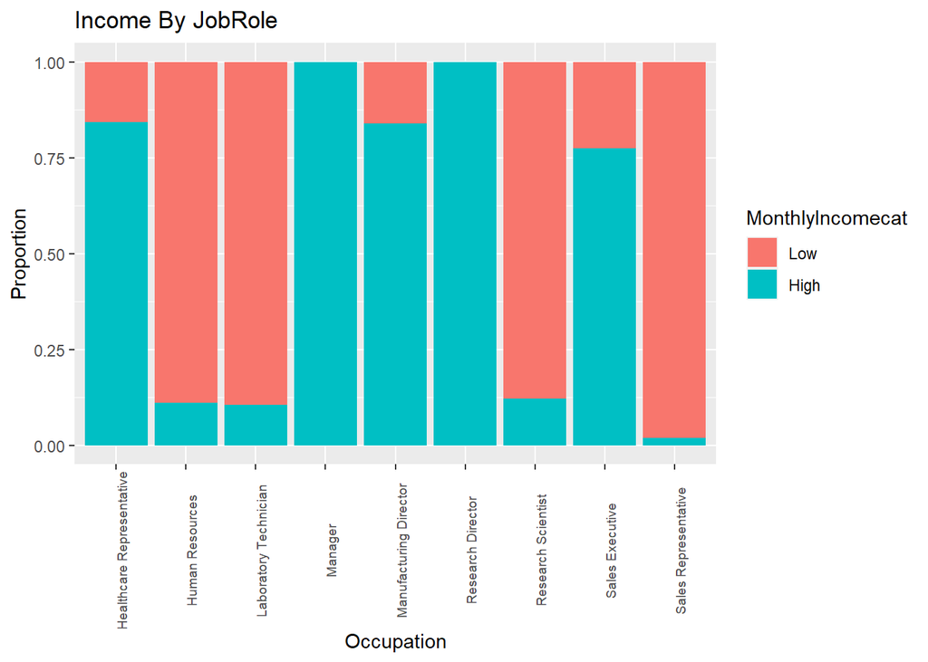

```r
#Job role and Monthly Income
ggplot(data = my_data3, aes(x = JobRole, fill = MonthlyIncomecat)) +
    geom_bar(position = "fill") + ggtitle("Income By JobRole") +
  theme(axis.text.x=element_text(size=rel(0.8), angle=90)) + labs(x="Occupation",y="Proportion")
```

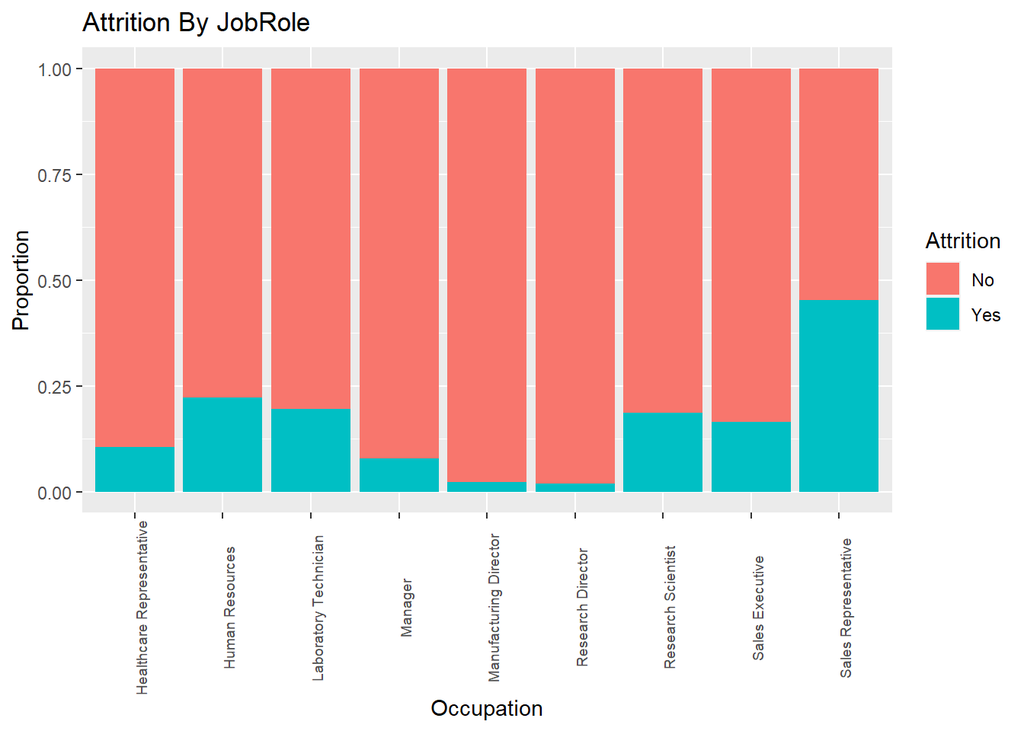

```r
#Job role and Attrition
ggplot(data = my_data3, aes(x = JobRole, fill = Attrition)) +
    geom_bar(position = "fill") + ggtitle("Attrition By JobRole") +
  theme(axis.text.x=element_text(size=rel(0.8), angle=90)) + labs(x="Occupation",y="Proportion")
```

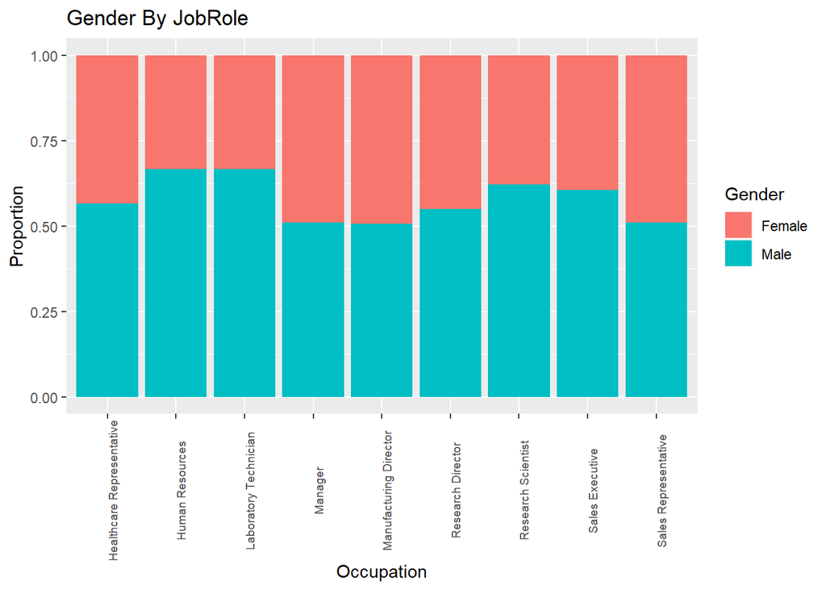

```r
#Job role and Gender

ggplot(data = my_data3, aes(x = JobRole, fill = Gender)) +
    geom_bar(position = "fill") + ggtitle("Gender By JobRole") +
  theme(axis.text.x=element_text(size=rel(0.8), angle=90)) + labs(x="Occupation",y="Proportion")
```

[figure not shown]

```r
#Job role and YearsAtCompany

ggplot(data = my_data3, aes(x = JobRole, fill = MaritalStatus)) +
    geom_bar(position = "fill") + ggtitle("TrainingTimesLastYear By JobRole") +
  theme(axis.text.x=element_text(size=rel(0.8), angle=90)) + labs(x="Occupation",y="Proportion")
```

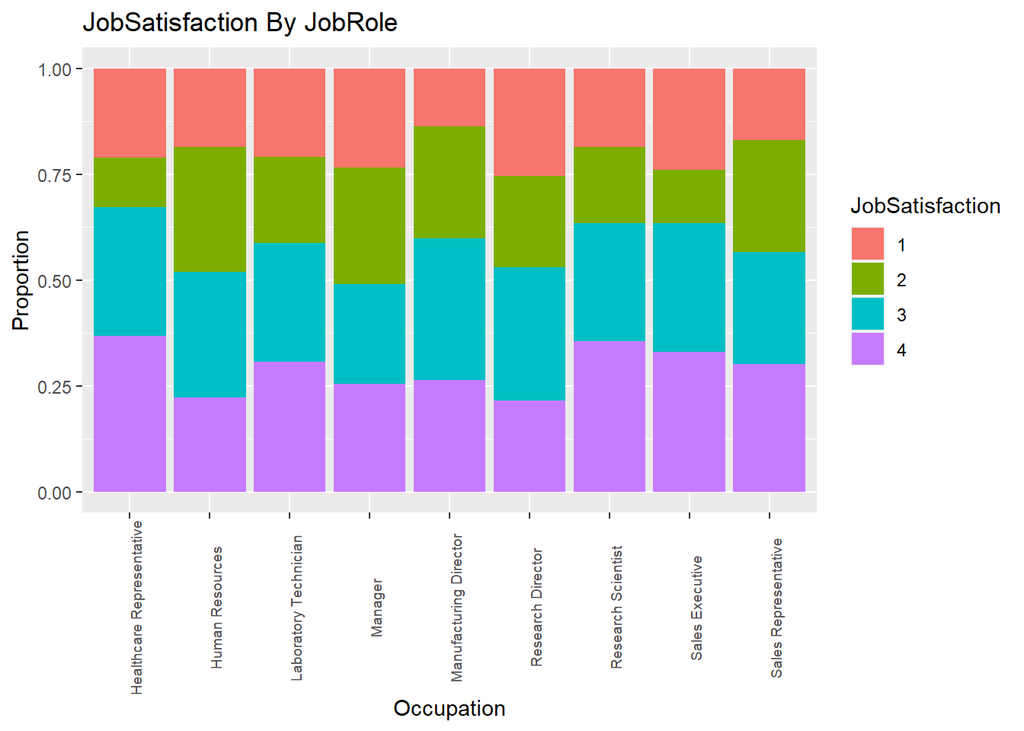

```r
#Job role and Job Satistication

ggplot(data = my_data3, aes(x = JobRole, fill = JobSatisfaction)) +
    geom_bar(position = "fill") + ggtitle("JobSatisfaction By JobRole") +
  theme(axis.text.x=element_text(size=rel(0.8), angle=90)) + labs(x="Occupation",y="Proportion")
```

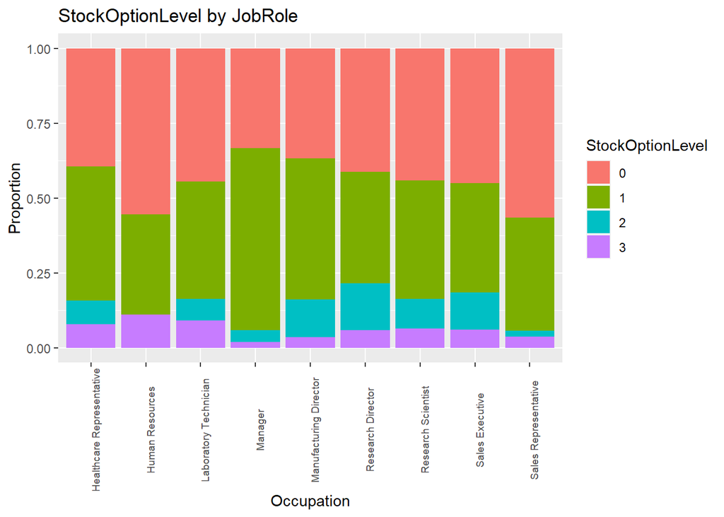

```r
#Job role and  StockOptionLevel

ggplot(data = my_data3, aes(x = JobRole, fill = StockOptionLevel)) +
    geom_bar(position = "fill") + ggtitle("StockOptionLevel by JobRole") +
  theme(axis.text.x=element_text(size=rel(0.8), angle=90)) + labs(x="Occupation",y="Proportion")
```

Provide any other interesting trends and observations from your analysis

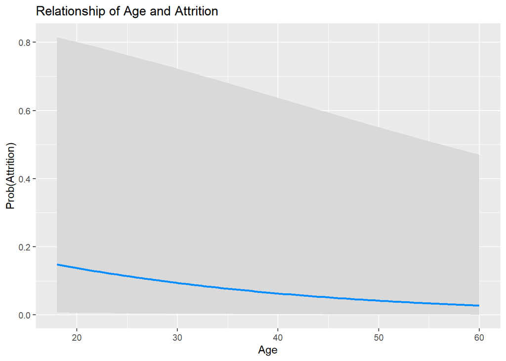

```r
my_data3glm <- glm(Attrition ~ .,
                 family="binomial",
                 data=my_data3)

#Attrition for Age
visreg(my_data3glm, "Age",
       gg = TRUE,
       scale="response", partial=FALSE, rug=FALSE) +
  labs(y = "Prob(Attrition)",
       x = "Age",
       title = "Relationship of Age and Attrition")
```

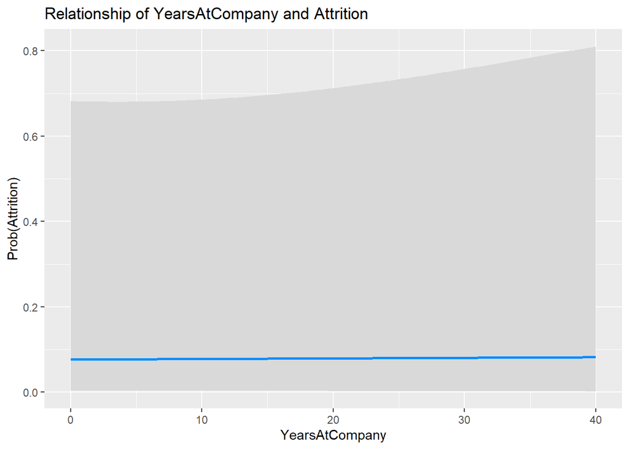

```r
#Attrition for Years At company
visreg(my_data3glm, "YearsAtCompany",
       gg = TRUE,
       scale="response", partial=FALSE, rug=FALSE) +
  labs(y = "Prob(Attrition)",
       x = "YearsAtCompany",
       title = "Relationship of YearsAtCompany and Attrition")
```

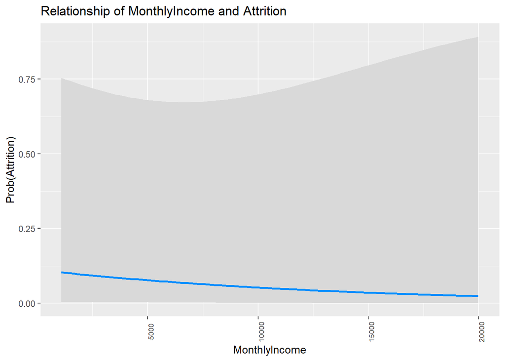

```r
#Attrition for Monthly Income
visreg(my_data3glm, "MonthlyIncome",
       gg = TRUE,
       scale="response", partial=FALSE, rug=FALSE) +
  labs(y = "Prob(Attrition)",
       x = "MonthlyIncome",
       title = "Relationship of MonthlyIncome and Attrition") + theme(axis.text.x=element_text(size=rel(0.8), angle=90))
```

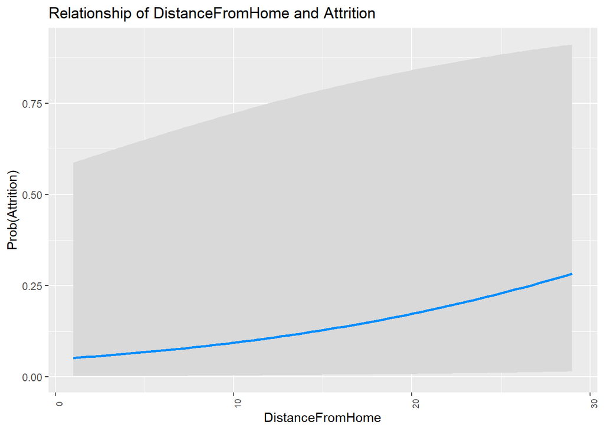

```r
#Attrition for Distance From Home
visreg(my_data3glm, "DistanceFromHome",
       gg = TRUE,
       scale="response", partial=FALSE, rug=FALSE) +
  labs(y = "Prob(Attrition)",
       x = "DistanceFromHome",
       title = "Relationship of DistanceFromHome and Attrition") + theme(axis.text.x=element_text(size=rel(0.8), angle=90))
```

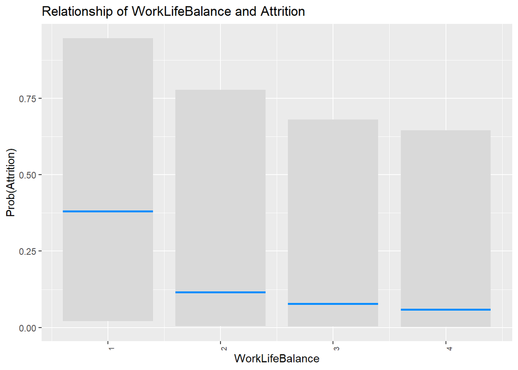

```r
#Attrition for WorkLifeBalance
visreg(my_data3glm, "WorkLifeBalance",
       gg = TRUE,
       scale="response", partial=FALSE, rug=FALSE) +
  labs(y = "Prob(Attrition)",
       x = "WorkLifeBalance",
       title = "Relationship of WorkLifeBalance and Attrition") + theme(axis.text.x=element_text(size=rel(0.8), angle=90))
```

[figure not shown]

```r
#Attrition for JobSatisfaction
visreg(my_data3glm, "JobSatisfaction",
       gg = TRUE,
       scale="response", partial=FALSE, rug=FALSE) +
  labs(y = "Prob(Attrition)",
       x = "Job Role",
       title = "Relationship of JobSatisfaction and Attrition") + theme(axis.text.x=element_text(size=rel(0.8), angle=90))
```